# GAM en series de tiempo: Prophet

Juan Manuel Barriola y Sofia Perini

13 de Noviembre de 2021

```r
library(dplyr)
library(ggplot2)
library(prophet)
library(lubridate)
library(cowplot)
```

## Problema

Queremos **predecir el número de visitantes de un local de ropa** en un determinado momento.

### Carga de datos

El dataset consiste en información real de 8 meses de visitantes de un local de ropa localizado en un shopping de gran tamaño.

```r
shopping <- read.csv('local-shopping_prophet.csv') %>%
  rename(.,visitantes=Total.de.Visitantes) %>%
  mutate(Dia = ymd(Dia))
glimpse(shopping)
```

```
Rows: 228
Columns: 3
$ Dia        <date> 2017-09-14, 2017-09-15, 2017-09-16, 2017-09-17, 2017-09-18, 2017-09-19, 2017-09-20, 2017-09-21, 2017-09…
$ visitantes <int> 589, 696, 1034, 940, 540, 526, 312, 553, 639, 793, 745, 8, 333, 568, 352, 393, 497, 578, 563, 520, 413, …
$ Clima      <chr> "Parcialmente Nublado", "Soleado", "Soleado", "Parcialmente Nublado", "Soleado", "Soleado", "Soleado", "…
```

Se observa que la serie de tiempo presenta un comportamiento cíclico con algunos eventos atípicos:

- Aumentos debidos a promociones y Navidad
- Caídas por cierre del local o caídas del sistema de medición

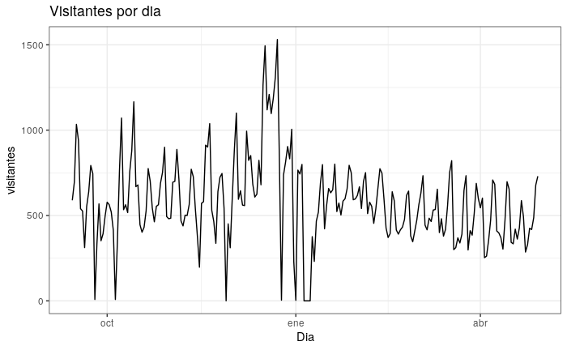

```r
ggplot(shopping, aes(Dia, visitantes)) + geom_line() + theme_bw() + labs(title='Visitantes por dia')
```

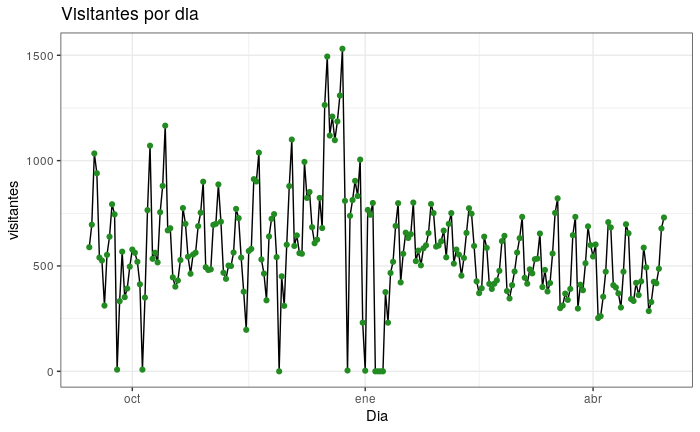

```r
ggplot(shopping, aes(Dia, visitantes)) + geom_line() + geom_point(color='forestgreen') + theme_bw() + labs(title='Visitantes por dia')
```

# Técnicas de suavizado

Una primera aproximación puede ser tratar de utilizar técnicas de suavizado.

En este caso estamos utilizando **loess** como una herramienta gráfica con el comando `geom_smooth()` de ggplot.

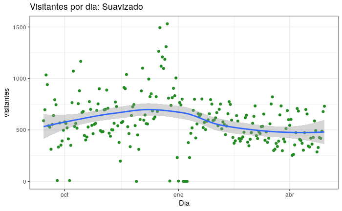

```r
ggplot(shopping, aes(Dia, visitantes)) + geom_point(color='forestgreen') + geom_smooth() + theme_bw() + labs(title='Visitantes por dia: Suavizado')
```

Si bien está suavizando, el resultado es bastante pobre ya que el modelo no está logrando representar bien la variabilidad de los datos.

## Distintas ventanas

Ahora realizamos 4 modelos de LOESS modificando la ventana (**span**) para cada uno de ellos.

Especificamos:

*formula*: fórmula que especifica la respuesta numérica y el predictor numérico.

*na.acción*: la acción que se realizará con valores NA en la respuesta o predictores.

*model*: ¿Debería devolverse el dataframe del modelo? (T/F)

*span*: el parámetro α que controla el grado de suavizado.

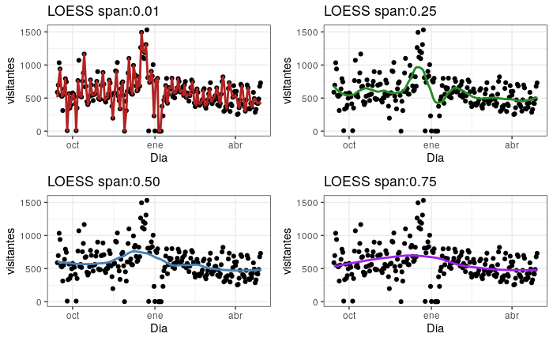

```r
loess=stats::loess(visitantes~as.numeric(Dia), data = shopping, na.action = 'na.exclude', model = T, span=0.01)
shopping['loess']=predict(loess,shopping)
loess_1 = ggplot(shopping, aes(Dia,visitantes)) + geom_point() + geom_line(aes(y=loess), color='firebrick', size=1) +
  labs(title= "LOESS span:0.01") + theme_bw()

loess=stats::loess(visitantes~as.numeric(Dia), data = shopping, na.action = 'na.exclude', model = T, span=0.25)
shopping['loess']=predict(loess,shopping)
loess_2 = ggplot(shopping, aes(Dia,visitantes)) + geom_point() + geom_line(aes(y=loess), color='forestgreen', size=1) +
  labs(title= "LOESS span:0.25") + theme_bw()

loess=stats::loess(visitantes~as.numeric(Dia), data = shopping, na.action = 'na.exclude', model = T, span=0.5)
shopping['loess']=predict(loess,shopping)
loess_3 = ggplot(shopping, aes(Dia,visitantes)) + geom_point() + geom_line(aes(y=loess), color='steelblue', size=1) +
  labs(title= "LOESS span:0.50") + theme_bw()

loess=stats::loess(visitantes~as.numeric(Dia), data = shopping, na.action = 'na.exclude', model = T, span=0.75)
shopping['loess']=predict(loess,shopping)
loess_4 = ggplot(shopping, aes(Dia,visitantes)) + geom_point() + geom_line(aes(y=loess), color='purple', size=1) +
  labs(title= "LOESS span:0.75") + theme_bw()

cowplot::plot_grid(loess_1, loess_2, loess_3,loess_4)
```

Se nota que para un **span muy pequeño** nuestro modelo va a tener un problema de **OVERFITTING**: no va a poder generalizar. Mientras que para **spans grandes** tenemos un problema de **UNDERFITTING**: nuestro modelo no logra captar bien la variabilidad del fenómeno.

# Prophet

Es un modelo para **pronosticar datos de series de tiempo basado en un modelo aditivo** donde las tendencias no lineales se ajustan a la estacionalidad anual, semanal y diaria, más los efectos de eventos especiales. Funciona mejor con series de tiempo que tienen fuertes efectos estacionales y varias temporadas de datos históricos. Es robusto ante datos faltantes y cambios de tendencia, y normalmente maneja bien valores atípicos.

[Prophet](https://facebook.github.io/prophet/) es un software de código abierto lanzado por Facebook. En este caso, vamos a trabajar sobre la implementación de Prophet en R.

## Preparacion del dataset

Prophet requiere que le pasemos el dataset con:

- **ds**: la variable temporal
- **y**: la variable a predecir

```r
# Eliminamos observaciones con menos de 250 visitantes (cuestion de negocio)
shopping[shopping['visitantes']<250,'visitantes'] = NA
# Creamos el dataset
prophet_df = shopping %>% select(Dia, visitantes) %>% rename(., ds=Dia, y=visitantes)
```

## Modelo

El modelo subyacente es el propuesto por Harvey & Peters (1990):

$y(t)=g(t)+s(t)+h(t)+\epsilon_t$

$y(t):$ variable a predecir

$g(t):$ función de tendencia

$s(t):$ cambios periódicos

$h(t):$fectos de vacaciones (eventos atípicos)$

$ε_t:$error

El modelo es similar a los GAM:

1. Cada variable es una función (posiblemente) no lineal del tiempo
2. Los efectos de los componentes se suman (efectos aditivos)

En palabras de los autores:

*“We are, in effect, framing the forecasting problem as a curvefitting exercise, which is inherently different from time series models that explicitly account for the temporal dependence structure in the data”* Taylor & Letham: *Forecasting at Scale* (2017)

Hay muchos parámetros para tener en cuenta. Veremos algunos:

- **df**: dataframe
- **growth**: tipo de tendencia: lineal o logistica
- **yearly.seasonality**: hay estacionalidad anual?
- **daily.seasonality**: hay estacionalidad diaria?
- **holidays**: dataframe con fechas de vacaciones/eventos especiales

### Modelo básico

La función `prophet` crea el modelo, podemos pasarle o no el dataframe.

La función `prophet.fit` aplica un modelo creado a un dataframe.

```r
# Llamamos solo al modelo
prophet_base = prophet()
# Le pasamos el dataset
prophet_base = fit.prophet(m = prophet_base, prophet_df)
```

```
Disabling yearly seasonality. Run prophet with yearly.seasonality=TRUE to override this.
Disabling daily seasonality. Run prophet with daily.seasonality=TRUE to override this.
```

Notemos que el modelo automáticamente deshabilita la estacionalidad anual y diaria.

#### Gráfico del modelo

Llamando a `plot` obtenemos el valor predicho del modelo y el valor original.

Es difícil de notar pero el modelo realiza predicciones aun para los dias en los cuales no hay datos.

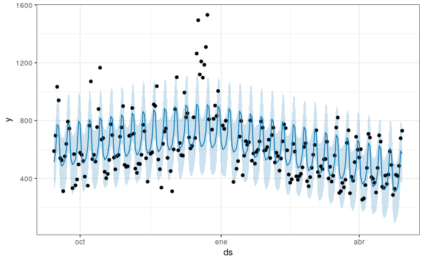

```r
plot(prophet_base,fcst=predict(prophet_base, prophet_df)) +theme_bw()
```

#### Componentes del modelo

La funcion `prophet_plot_components` nos devuelve los efectos de los componentes en nuestra variable a predecir.

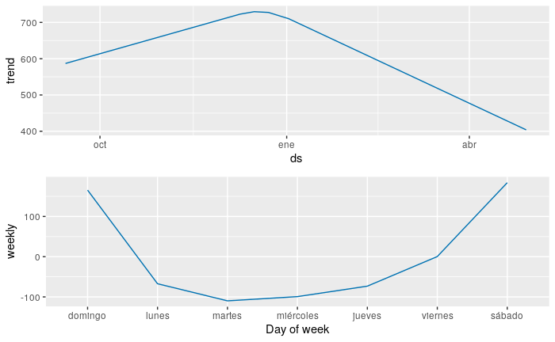

```r
prophet_plot_components(prophet_base, fcst=predict(prophet_base, prophet_df))
```

En este caso tenemos la tendencia de los visitantes y la estacionalidad semanal. Esta última parece tener bastante sentido ya que nos muestra que hay mayor cantidad de visitantes durante el fin de semana.

### Modelo con estacionalidad mensual

La función `add_seasonality` nos permite agregar nuevas estacionalidades. Las estacionalidades se modelan utilizando series de Fourier que nosotros debemos definir.

Definimos:

- **m**: modelo
- **name**: nombre de la estacionalidad
- **period**: cantidad de dias del periodo
- **fourier.order**: orden de la serie de fourier para modelar la estacionalidad

```r
# Llamamos solo al modelo
prophet_mensual=prophet()
# Agregamos la estacionalidad mensual
prophet_mensual=add_seasonality(m=prophet_mensual, name='monthly', period=365/12, fourier.order = 4)
# Le pasamos el dataset
prophet_mensual = fit.prophet(m = prophet_mensual, prophet_df)
```

```
Disabling yearly seasonality. Run prophet with yearly.seasonality=TRUE to override this.
Disabling daily seasonality. Run prophet with daily.seasonality=TRUE to override this.
```

Notemos que sigue deshabilitando la estacionalidad anual y diaria.

#### Gráfico del modelo

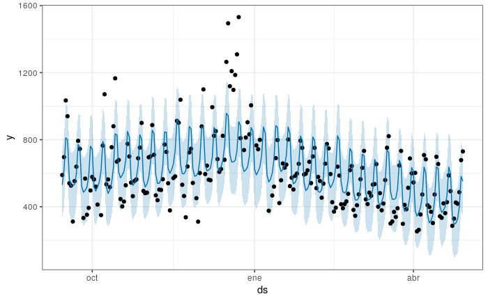

```r
plot(prophet_mensual,fcst=predict(prophet_mensual, prophet_df)) +theme_bw()
```

#### Componentes del modelo

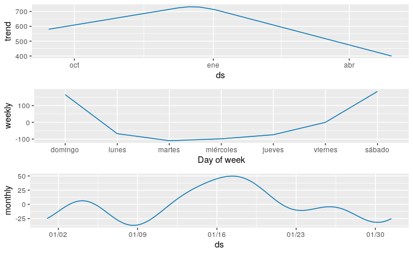

```r
prophet_plot_components(prophet_mensual, fcst=predict(prophet_mensual, prophet_df))
```

Notemos que la tendencia y estacionalidad semanal se mantiene y ahora se agrega la tendencia mensual que habíamos incorporado. Nos indica que el ciclo mensual se caracteriza por un crecimiento en la mitad de mes.

### Modelo completo

Como último paso vamos a agregar las ventas de navidad y ciertos dias de promociones como eventos especiales.

#### Dataframe de eventos

Creamos el dataframe de eventos con: nombre del evento, fechas y una “ventana” para definir si el evento se estira a ciertos dias.

```r
# Navidad
christmas = data.frame(holiday= 'christmas',
  ds=ymd(c('2017-12-16','2017-12-17','2017-12-18',
                        '2017-12-19','2017-12-20','2017-12-21',
                        '2017-12-22','2017-12-23')),
  lower_window= 0,
  upper_window= 0)

# Promociones
big_sales = data.frame(
  holiday= 'big_sales',
  ds= ymd(c('2017-09-16','2017-10-08','2017-10-14',
                        '2017-11-20','2017-12-03','2017-12-30')),
  lower_window= 0,
  upper_window= 0)

holidays= bind_rows(christmas, big_sales)
glimpse(holidays)
```

```
Rows: 14
Columns: 4
$ holiday      <chr> "christmas", "christmas", "christmas", "christmas", "christmas", "christmas", "christmas", "christmas"…
$ ds           <date> 2017-12-16, 2017-12-17, 2017-12-18, 2017-12-19, 2017-12-20, 2017-12-21, 2017-12-22, 2017-12-23, 2017-…
$ lower_window <dbl> 0, 0, 0, 0, 0, 0, 0, 0, 0, 0, 0, 0, 0, 0
$ upper_window <dbl> 0, 0, 0, 0, 0, 0, 0, 0, 0, 0, 0, 0, 0, 0
```

```r
# Llamamos al modelo con el dataset de eventos
prophet_full=prophet(holidays = holidays)
# Agregamos la estacionalidad mensual
prophet_full=add_seasonality(prophet_full, name='monthly', period=30.5, fourier.order = 4)
# Le pasamos el dataset
prophet_full = fit.prophet(m = prophet_full, prophet_df)
```

```
Disabling yearly seasonality. Run prophet with yearly.seasonality=TRUE to override this.
Disabling daily seasonality. Run prophet with daily.seasonality=TRUE to override this.
```

Fijense que el modelo automáticamente deshabilita la estacionalidad anual y diaria.

#### Gráfico del modelo

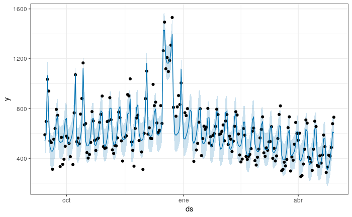

```r
plot(prophet_full,fcst=predict(prophet_full, prophet_df)) +theme_bw()
```

#### Componentes del modelo

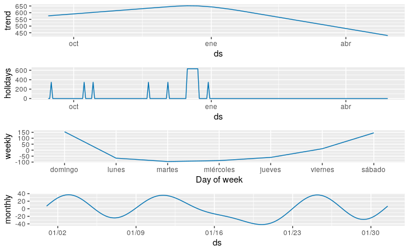

```r
prophet_plot_components(prophet_full, fcst=predict(prophet_full, prophet_df))
```

## Evaluación del modelo

La funcion `cross_validation` permite realizar pronósticos realizando un esquema de cross-validation temporal y, a partir de ellos, obtener ciertas métricas de performance.

- **horizon**: horizonte del pronóstico. Cuánto tiempo deseo predecir
- **period**: período entre fechas de análisis. Cuánto voy corriendo mi ventana
- **initial**: período inicial de entrenamiento
- **units**: unidad de tiempo utilizada

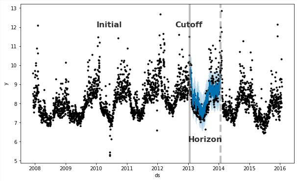

La función `cross_validation` devuelve un dataframe en el cual para cada grupo/fold de **cutoff** se obtiene para cada fecha dentro del **horizonte**: valor predicho, valor inferior del intervalo y valor superior del intervalo.

Una vez que se obtiene este dataframe se pueden obtener métricas de evaluación con la función `performance_metrics`. Definimos la proporción de datos que se utilizarán en cada ventana móvil para calcular las métricas (`rolling_window`).

El procedimiento es el siguiente:

1. Se calcula el horizonte de predicción de cada observación: ds - cutoff
2. Se ordena de menor a mayor horizonte
3. Se calculan las métricas con la cantidad de observaciones definidas por **rolling_window**.
1. Comienza realizandolo para cada horizonte
2. Si los datos dentro de un **horizonte** no son suficientes comienza a usar observaciones de horizontes aledaños.

Entonces, según el valor de **rolling_window** se tienen los siguientes casos:

- **rolling_window** < 0: se calculan las métricas para cada observación por separado
- **rolling_window** = 0: se calculan las métricas para cada horizonte por separado
- **rolling_window** 0 < w < 1: se calculan las métricas para cada horizonte usando el x% de las observaciones del dataframe
- **rolling_window** = 1: se calculan las métricas para todas las observaciones

Realicemos la evaluación para nuestros modelos

### Modelo básico

Usamos `cross_validation` con un periodo inicial de 45 días, un horizonte de 15 días y desplazaremos la predicción cada 7 días

```r
cv_base = cross_validation(prophet_base, initial = 45, period = 7, horizon = 15, units = 'days')
```

```
Making 24 forecasts with cutoffs between 2017-11-04 and 2018-04-14
```

```r
cv_base
```

| y | ds | yhat | yhat_lower | yhat_upper | cutoff |
| --- | --- | --- | --- | --- | --- |
| 710 | 2017-11-05 | 827.5072 | 655.33128 | 988.8908 | 2017-11-04 |
| 468 | 2017-11-06 | 583.8158 | 425.51278 | 745.8201 | 2017-11-04 |
| 439 | 2017-11-07 | 503.0724 | 333.26169 | 665.5611 | 2017-11-04 |
| 502 | 2017-11-08 | 491.3577 | 312.40547 | 660.2783 | 2017-11-04 |
| 500 | 2017-11-09 | 592.5476 | 424.63183 | 753.5929 | 2017-11-04 |
| 564 | 2017-11-10 | 639.8363 | 468.76730 | 801.4129 | 2017-11-04 |
| 771 | 2017-11-11 | 864.2158 | 698.87499 | 1041.9310 | 2017-11-04 |
| 727 | 2017-11-12 | 834.2786 | 643.94248 | 999.4082 | 2017-11-04 |
| 540 | 2017-11-13 | 590.5872 | 409.28166 | 762.9385 | 2017-11-04 |
| 378 | 2017-11-14 | 509.8438 | 334.48143 | 673.2882 | 2017-11-04 |

[output cut: 328 more lines]

Obtenemos las métricas de performance

```r
performance_metrics(cv_base, rolling_window = 0.25)
```

| horizon | mse | rmse | mae | mape | mdape | smape | coverage |
| --- | --- | --- | --- | --- | --- | --- | --- |
| 4 days | 36150.05 | 190.1317 | 130.4435 | 0.2183031 | 0.1788814 | 0.2070826 | 0.8777056 |
| 5 days | 32659.76 | 180.7201 | 122.4637 | 0.2284015 | 0.1816296 | 0.2130551 | 0.8707483 |
| 6 days | 35228.29 | 187.6920 | 127.6135 | 0.2261772 | 0.1719579 | 0.2109508 | 0.8416149 |
| 7 days | 42634.43 | 206.4811 | 145.7300 | 0.2282670 | 0.1689692 | 0.2108974 | 0.7781385 |
| 8 days | 50632.79 | 225.0173 | 164.6296 | 0.2385913 | 0.1656195 | 0.2184160 | 0.7460317 |
| 9 days | 53515.72 | 231.3347 | 169.7358 | 0.2475610 | 0.1823478 | 0.2269221 | 0.7417184 |
| 10 days | 52334.91 | 228.7683 | 166.8692 | 0.2602884 | 0.2250754 | 0.2375654 | 0.7562112 |
| 11 days | 45625.78 | 213.6019 | 153.5599 | 0.2594442 | 0.2190272 | 0.2424267 | 0.7846320 |
| 12 days | 45043.81 | 212.2353 | 153.6584 | 0.2810819 | 0.2412885 | 0.2596109 | 0.7312925 |
| 13 days | 47644.88 | 218.2771 | 159.2416 | 0.2797656 | 0.2142858 | 0.2585741 | 0.6992754 |

[output cut: 2 more lines]

#### Breve explicación de la construcción de las métricas

Construimos el horizonte para nuestro set de predicciones

```r
# Construimos el horizonte
cv_base_explicacion = cv_base %>% mutate(horizon = ds-cutoff)
cv_base_explicacion[order(cv_base_explicacion$horizon),]
```

|  | y | ds | yhat | yhat_lower | yhat_upper | cutoff | horizon |
| --- | --- | --- | --- | --- | --- | --- | --- |
| 1 | 710 | 2017-11-05 | 827.5072 | 655.33128 | 988.8908 | 2017-11-04 | 1 days |
| 15 | 727 | 2017-11-12 | 793.4792 | 618.25913 | 945.5144 | 2017-11-11 | 1 days |
| 29 | 901 | 2017-11-19 | 780.8125 | 628.17490 | 936.3844 | 2017-11-18 | 1 days |
| 43 | 746 | 2017-11-26 | 806.4763 | 632.56039 | 981.1168 | 2017-11-25 | 1 days |
| 57 | 1100 | 2017-12-03 | 788.5375 | 618.35080 | 956.9719 | 2017-12-02 | 1 days |
| 72 | 851 | 2017-12-10 | 851.0757 | 681.16650 | 1027.4744 | 2017-12-09 | 1 days |
| 87 | 1494 | 2017-12-17 | 887.0683 | 715.20188 | 1073.7476 | 2017-12-16 | 1 days |
| 100 | 809 | 2017-12-24 | 1203.2751 | 1006.41965 | 1411.1441 | 2017-12-23 | 1 days |
| 129 | 798 | 2018-01-14 | 1044.2203 | 768.09483 | 1300.5862 | 2018-01-13 | 1 days |
| 144 | 523 | 2018-01-21 | 1007.9624 | 745.17061 | 1255.7634 | 2018-01-20 | 1 days |

[output cut: 328 more lines]

Observemos cuantas observaciones tenemos por horizonte

```r
cv_base_explicacion %>% group_by(horizon) %>% count()
```

| horizon | n |
| --- | --- |
| 1 days | 22 |
| 2 days | 21 |
| 3 days | 23 |
| 4 days | 22 |
| 5 days | 24 |
| 6 days | 23 |
| 7 days | 23 |
| 8 days | 22 |
| 9 days | 21 |
| 10 days | 23 |

[output cut: 5 more lines]

La ventana se define de la siguiente manera:

```r
# El código se adaptó del código fuente de la librería
n_observaciones_ventana = function(rolling_window, cv_df){
  w <- as.integer(rolling_window * nrow(cv_df))
    if (w >= 0) {
      w <- max(w, 1)
      w <- min(w, nrow(cv_df))
    }
  return(w)
}
```

**Rolling window < 0**

```r
rolling_window = -1
# Cantidad de observaciones
n_observaciones_ventana(rolling_window, cv_base)
```

```
[1] -338
```

```r
# Set de metricas
performance_metrics(cv_base, rolling_window=rolling_window)
```

| horizon | mse | rmse | mae | mape | mdape | smape | coverage |
| --- | --- | --- | --- | --- | --- | --- | --- |
| 1 days | 1.380794e+04 | 117.5071863 | 117.5071863 | 0.1655030792 | 0.1655030792 | 1.528542e-01 | TRUE |
| 1 days | 4.419482e+03 | 66.4791883 | 66.4791883 | 0.0914431750 | 0.0914431750 | 8.744505e-02 | TRUE |
| 1 days | 1.444504e+04 | 120.1875080 | 120.1875080 | 0.1333934606 | 0.1333934606 | 1.429262e-01 | TRUE |
| 1 days | 3.657384e+03 | 60.4763056 | 60.4763056 | 0.0810674338 | 0.0810674338 | 7.790947e-02 | TRUE |
| 1 days | 9.700888e+04 | 311.4624899 | 311.4624899 | 0.2831477181 | 0.2831477181 | 3.298452e-01 | FALSE |
| 1 days | 5.727402e-03 | 0.0756796 | 0.0756796 | 0.0000889302 | 0.0000889302 | 8.892624e-05 | TRUE |
| 1 days | 3.683661e+05 | 606.9317375 | 606.9317375 | 0.4062461429 | 0.4062461429 | 5.097978e-01 | FALSE |
| 1 days | 1.554529e+05 | 394.2751238 | 394.2751238 | 0.4873610925 | 0.4873610925 | 3.918700e-01 | FALSE |
| 1 days | 6.062441e+04 | 246.2202517 | 246.2202517 | 0.3085466813 | 0.3085466813 | 2.673082e-01 | TRUE |
| 1 days | 2.351885e+05 | 484.9624046 | 484.9624046 | 0.9272703721 | 0.9272703721 | 6.335393e-01 | FALSE |

[output cut: 328 more lines]

**Rolling window = 0**

```r
rolling_window = 0
# Cantidad de observaciones
n_observaciones_ventana(rolling_window, cv_base)
```

```
[1] 1
```

```r
# Set de metricas
performance_metrics(cv_base, rolling_window=rolling_window)
```

| horizon | mse | rmse | mae | mape | mdape | smape | coverage |
| --- | --- | --- | --- | --- | --- | --- | --- |
| 1 days | 51306.44 | 226.5092 | 166.54205 | 0.2130237 | 0.1488970 | 0.1975559 | 0.8181818 |
| 2 days | 40851.80 | 202.1183 | 146.33590 | 0.2597010 | 0.2474697 | 0.2443545 | 0.8095238 |
| 3 days | 36580.08 | 191.2592 | 129.75994 | 0.2499598 | 0.2035829 | 0.2308974 | 0.9130435 |
| 4 days | 18811.75 | 137.1559 | 86.45275 | 0.1500107 | 0.1295847 | 0.1544023 | 0.9545455 |
| 5 days | 36476.76 | 190.9889 | 133.56147 | 0.2600376 | 0.1767402 | 0.2301592 | 0.7916667 |
| 6 days | 48746.70 | 220.7865 | 159.37815 | 0.2481893 | 0.1736001 | 0.2319886 | 0.7391304 |
| 7 days | 57448.33 | 239.6838 | 180.86124 | 0.2228270 | 0.1515805 | 0.2040954 | 0.6956522 |
| 8 days | 55774.57 | 236.1664 | 175.74523 | 0.2294405 | 0.1626858 | 0.2106574 | 0.7727273 |
| 9 days | 50929.90 | 225.6765 | 160.13333 | 0.2930957 | 0.3349517 | 0.2646191 | 0.7619048 |
| 10 days | 46325.84 | 215.2344 | 153.57878 | 0.2891584 | 0.2311163 | 0.2647962 | 0.7826087 |

[output cut: 5 more lines]

**Rolling window = 0.25**

```r
rolling_window = 0.25
# Cantidad de observaciones
n_observaciones_ventana(rolling_window, cv_base)
```

```
[1] 84
```

```r
# Set de metricas
performance_metrics(cv_base, rolling_window=rolling_window)
```

| horizon | mse | rmse | mae | mape | mdape | smape | coverage |
| --- | --- | --- | --- | --- | --- | --- | --- |
| 4 days | 36150.05 | 190.1317 | 130.4435 | 0.2183031 | 0.1788814 | 0.2070826 | 0.8777056 |
| 5 days | 32659.76 | 180.7201 | 122.4637 | 0.2284015 | 0.1816296 | 0.2130551 | 0.8707483 |
| 6 days | 35228.29 | 187.6920 | 127.6135 | 0.2261772 | 0.1719579 | 0.2109508 | 0.8416149 |
| 7 days | 42634.43 | 206.4811 | 145.7300 | 0.2282670 | 0.1689692 | 0.2108974 | 0.7781385 |
| 8 days | 50632.79 | 225.0173 | 164.6296 | 0.2385913 | 0.1656195 | 0.2184160 | 0.7460317 |
| 9 days | 53515.72 | 231.3347 | 169.7358 | 0.2475610 | 0.1823478 | 0.2269221 | 0.7417184 |
| 10 days | 52334.91 | 228.7683 | 166.8692 | 0.2602884 | 0.2250754 | 0.2375654 | 0.7562112 |
| 11 days | 45625.78 | 213.6019 | 153.5599 | 0.2594442 | 0.2190272 | 0.2424267 | 0.7846320 |
| 12 days | 45043.81 | 212.2353 | 153.6584 | 0.2810819 | 0.2412885 | 0.2596109 | 0.7312925 |
| 13 days | 47644.88 | 218.2771 | 159.2416 | 0.2797656 | 0.2142858 | 0.2585741 | 0.6992754 |

[output cut: 2 more lines]

**Rolling window = 1**

```r
rolling_window = 1
# Cantidad de observaciones
n_observaciones_ventana(rolling_window, cv_base)
```

```
[1] 338
```

```r
# Set de metricas
performance_metrics(cv_base, rolling_window=rolling_window)
```

| horizon | mse | rmse | mae | mape | mdape | smape | coverage |
| --- | --- | --- | --- | --- | --- | --- | --- |
| 15 days | 49006.87 | 221.3749 | 158.2815 | 0.2513091 | 0.1865994 | 0.2315155 | 0.760355 |

### Modelo mensual

Usamos `cross_validation` con un periodo inicial de 45 días, un horizonte de 15 días y desplazaremos la predicción cada 7 días

```r
cv_mensual = cross_validation(prophet_mensual, initial = 45, period = 7, horizon = 15, units = 'days')
```

```
Making 24 forecasts with cutoffs between 2017-11-04 and 2018-04-14
```

```r
cv_mensual
```

| y | ds | yhat | yhat_lower | yhat_upper | cutoff |
| --- | --- | --- | --- | --- | --- |
| 710 | 2017-11-05 | 822.1001 | 689.06703 | 970.6542 | 2017-11-04 |
| 468 | 2017-11-06 | 543.0680 | 409.57052 | 673.6058 | 2017-11-04 |
| 439 | 2017-11-07 | 454.5758 | 319.97188 | 583.2580 | 2017-11-04 |
| 502 | 2017-11-08 | 496.4709 | 355.71609 | 626.0040 | 2017-11-04 |
| 500 | 2017-11-09 | 671.5231 | 525.36329 | 814.6526 | 2017-11-04 |
| 564 | 2017-11-10 | 820.6870 | 680.85421 | 954.1520 | 2017-11-04 |
| 771 | 2017-11-11 | 1101.9276 | 967.01026 | 1250.0006 | 2017-11-04 |
| 727 | 2017-11-12 | 1072.3849 | 933.41316 | 1211.1822 | 2017-11-04 |
| 540 | 2017-11-13 | 786.2759 | 643.04482 | 920.0347 | 2017-11-04 |
| 378 | 2017-11-14 | 640.9658 | 494.18149 | 774.8893 | 2017-11-04 |

[output cut: 328 more lines]

Obtenemos las métricas de performance

```r
performance_metrics(cv_mensual, rolling_window = 0.25)
```

| horizon | mse | rmse | mae | mape | mdape | smape | coverage |
| --- | --- | --- | --- | --- | --- | --- | --- |
| 4 days | 39971.18 | 199.9279 | 138.3492 | 0.2391455 | 0.1870001 | 0.2251424 | 0.7554113 |
| 5 days | 37809.29 | 194.4461 | 134.6912 | 0.2543003 | 0.2081792 | 0.2377570 | 0.7704082 |
| 6 days | 42464.42 | 206.0690 | 143.8981 | 0.2583914 | 0.1931538 | 0.2406175 | 0.7510352 |
| 7 days | 51611.73 | 227.1822 | 162.9163 | 0.2582892 | 0.1931538 | 0.2373569 | 0.6991342 |
| 8 days | 60995.34 | 246.9723 | 180.7727 | 0.2666791 | 0.1821804 | 0.2398642 | 0.6706349 |
| 9 days | 64367.10 | 253.7067 | 185.7541 | 0.2788594 | 0.1947795 | 0.2492932 | 0.6635611 |
| 10 days | 60865.78 | 246.7099 | 178.4146 | 0.2870169 | 0.2175230 | 0.2552442 | 0.6780538 |
| 11 days | 52317.78 | 228.7308 | 163.6091 | 0.2856056 | 0.2168539 | 0.2621834 | 0.7391775 |
| 12 days | 51280.25 | 226.4514 | 163.1799 | 0.3034616 | 0.2552989 | 0.2794911 | 0.7380952 |
| 13 days | 56718.76 | 238.1570 | 173.0351 | 0.3055327 | 0.2382940 | 0.2827158 | 0.7313665 |

[output cut: 2 more lines]

### Modelo completo

Usamos `cross_validation` con un periodo inicial de 45 días, un horizonte de 15 días y desplazaremos la predicción cada 7 días

```r
cv_full = cross_validation(prophet_full, initial = 45, period = 7, horizon = 15, units = 'days')
```

```
Making 24 forecasts with cutoffs between 2017-11-04 and 2018-04-14
```

```r
cv_full
```

| y | ds | yhat | yhat_lower | yhat_upper | cutoff |
| --- | --- | --- | --- | --- | --- |
| 710 | 2017-11-05 | 789.0090 | 680.1892 | 902.7478 | 2017-11-04 |
| 468 | 2017-11-06 | 529.3885 | 415.5733 | 639.5990 | 2017-11-04 |
| 439 | 2017-11-07 | 408.8110 | 291.5880 | 519.5895 | 2017-11-04 |
| 502 | 2017-11-08 | 433.6865 | 321.9095 | 540.4654 | 2017-11-04 |
| 500 | 2017-11-09 | 618.6020 | 507.6916 | 722.8274 | 2017-11-04 |
| 564 | 2017-11-10 | 788.1399 | 681.3428 | 903.6840 | 2017-11-04 |
| 771 | 2017-11-11 | 1015.1674 | 902.0067 | 1131.2998 | 2017-11-04 |
| 727 | 2017-11-12 | 1030.4000 | 918.1663 | 1138.5929 | 2017-11-04 |
| 540 | 2017-11-13 | 781.0116 | 672.1649 | 893.1659 | 2017-11-04 |
| 378 | 2017-11-14 | 610.2952 | 488.8382 | 725.6349 | 2017-11-04 |

[output cut: 328 more lines]

Obtenemos las métricas de performance

```r
performance_metrics(cv_full, rolling_window = 0.25)
```

| horizon | mse | rmse | mae | mape | mdape | smape | coverage |
| --- | --- | --- | --- | --- | --- | --- | --- |
| 4 days | 14128.12 | 118.8617 | 94.10421 | 0.1807864 | 0.1403171 | 0.1691104 | 0.7294372 |
| 5 days | 16645.99 | 129.0193 | 100.86014 | 0.2079544 | 0.1707871 | 0.1914289 | 0.7108844 |
| 6 days | 21368.81 | 146.1808 | 109.51024 | 0.2087361 | 0.1627841 | 0.1929214 | 0.6956522 |
| 7 days | 25462.21 | 159.5688 | 121.59723 | 0.2018303 | 0.1636601 | 0.1884272 | 0.6720779 |
| 8 days | 31935.54 | 178.7052 | 133.18036 | 0.1990888 | 0.1582010 | 0.1865609 | 0.6428571 |
| 9 days | 33028.27 | 181.7368 | 134.91566 | 0.2039368 | 0.1623166 | 0.1914855 | 0.6516563 |
| 10 days | 33533.93 | 183.1227 | 132.55363 | 0.2136777 | 0.1669079 | 0.2008149 | 0.6516563 |
| 11 days | 31727.74 | 178.1228 | 123.98111 | 0.2177019 | 0.1828058 | 0.2081482 | 0.6839827 |
| 12 days | 32823.06 | 181.1714 | 128.27463 | 0.2420112 | 0.2035466 | 0.2299280 | 0.6666667 |
| 13 days | 37773.14 | 194.3531 | 135.07160 | 0.2369450 | 0.1944277 | 0.2274593 | 0.6283644 |

[output cut: 2 more lines]

### Gráficos

La función `plot_cross_validation_metric` nos permite graficar el comportamiento de una métrica de performance para los distintos horizontes

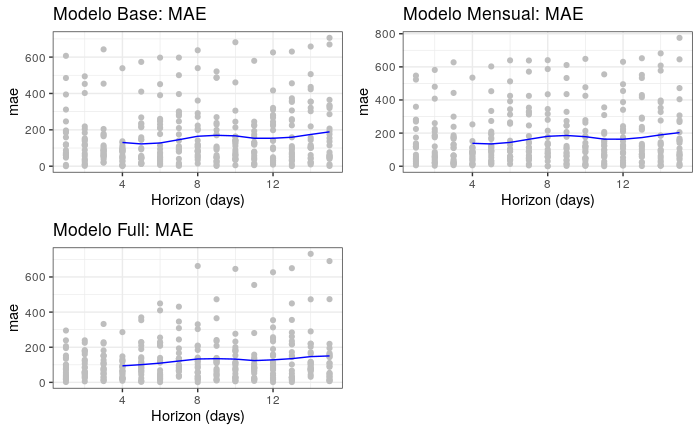

```r
mae_base = plot_cross_validation_metric(cv_base, metric = 'mae', rolling_window = 0.25) +
            theme_bw() + labs(title="Modelo Base: MAE")
mae_mensual = plot_cross_validation_metric(cv_mensual, metric = 'mae', rolling_window = 0.25) +
           theme_bw() + labs(title="Modelo Mensual: MAE")
mae_full = plot_cross_validation_metric(cv_full, metric = 'mae', rolling_window = 0.25) +
            theme_bw() + labs(title="Modelo Full: MAE")

cowplot::plot_grid(mae_base, mae_mensual, mae_full)
```

## Gráficos interactivos

Prophet también nos permite realizar gráficos interactivos que suelen ser muy útiles para presentar los resultados.

```r
dyplot.prophet(prophet_full, fcst=predict(prophet_full, prophet_df))
```

[interactive chart not shown]

## Fuentes

- Github: https://github.com/facebook/prophet
- Paper: https://peerj.com/preprints/3190.pdf
- Blog: https://research.fb.com/prophet-forecasting-at-scale/
- Documentacion: https://facebook.github.io/prophet/docs/